# HW #7

John Doll

```r
load("hockeyData.RData")
ls()
```

```
## [1] "hockey_test"  "hockey_train"
```

# Part 1 - Odds

## Question 1

Is there a home-ice advantage? Compute the odds the home team wins and discuss whether this implies there is a home ice advantage in the NHL?

```r
glimpse(hockey_train)
```

```
## Observations: 7,402
## Variables: 10
## $ game_id       <dbl> 2011030221, 2011030222, 2011030223, 2011030224, 2011030…
## $ hometeam_wins <lgl> TRUE, FALSE, TRUE, TRUE, FALSE, FALSE, FALSE, TRUE, FAL…
## $ game_finished <fct> Overtime, Regulation, Overtime, Regulation, Regulation,…
## $ Shot_diff     <dbl> 10, -15, 3, 21, -2, -8, 1, -1, -2, -7, 7, 13, -5, -10, …
## $ Hit_diff      <dbl> -4, -8, 2, -4, 12, 9, 3, 23, -10, 11, -14, 7, 3, 9, 16,…
## $ PIM_diff      <dbl> -6, 20, 6, -6, 6, -2, -4, 6, -2, 0, -41, -2, 8, -4, 0, …
## $ PPO_diff      <dbl> 3, 1, -3, 3, -3, 1, 2, -4, 1, 0, 7, 1, -4, 2, 0, 1, 0, …
## $ Giveaway_diff <dbl> 7, 1, 9, -15, 8, 5, 7, 6, 4, -1, 5, -13, 15, -3, 1, 7, …
## $ Takeaway_diff <dbl> -3, -1, 3, -2, 2, 4, 4, 1, 1, 3, 4, -2, 2, 2, 1, 6, 4, …
## $ home_faceoff  <dbl> 55.1, 49.1, 49.2, 37.5, 45.0, 44.6, 46.5, 56.6, 46.0, 5…
```

```r
xtabs(~ hometeam_wins, data = hockey_train)
```

```
## hometeam_wins
## FALSE  TRUE
##  3343  4059
```

### Answer

The odds that the home team wins is (4059/3343) = 1.214.

## Question 2

Does any home-ice advantage get mitigated when a game goes to overtime or in a shootout? Compute the odds the home team wins in regulation, overtime or a shootout. Compare these values to address the question.

```r
xtabs(~ hometeam_wins + game_finished, data = hockey_train)
```

```
##              game_finished
## hometeam_wins Regulation Overtime Shootout
##         FALSE       2476      446      421
##         TRUE        3143      505      411
```

### Answer

The odds that the home team wins in

- regulation is (3143/2476) = 1.269
- overtime is (505/446) = 1.132
- shootout is (411/421) = 0.9762

While the odds are greatest for the home team to win in regulation. and 2nd greatest for overtime, the odds are slightly in favor of the away team in a shootout. So from this, it would appear that home-ice advantage is mitigated when the game goes to a shoot-out, and the home-ice advantage is weakened when the game goes to overtime.

# Part 2 EDA and basic question

## Question 3

Build a plot to explore how the difference between home and away shots on goal predicts whether the home team wins. Briefly discuss the results of your plot.

### Answer

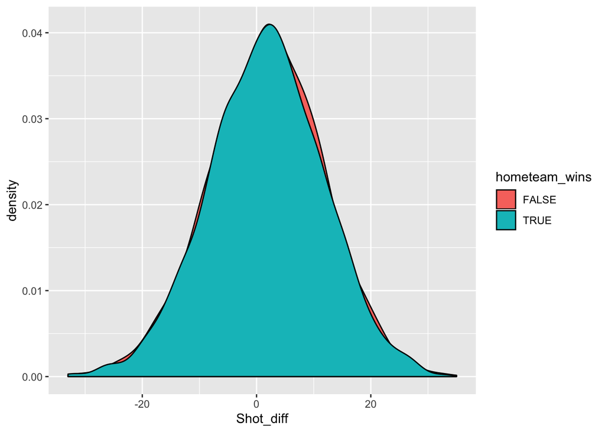

```r
ggplot(hockey_train) +
  geom_density(aes(Shot_diff, fill = hometeam_wins))
```

From my plot it would appear that the shot differential does not play a major role in whether or not the home team won the game.

## Question 4

Build a simple logistic model to statistically determine if the difference in shots on goal predicts the probability the home team wins.

### Answer

```r
shots.fit <- glm(hometeam_wins ~ Shot_diff, data = hockey_train, family = binomial(link = logit))
summary(shots.fit)
```

```
##
## Call:
## glm(formula = hometeam_wins ~ Shot_diff, family = binomial(link = logit),
##     data = hockey_train)
##
## Deviance Residuals:
##    Min      1Q  Median      3Q     Max
## -1.267  -1.261   1.094   1.096   1.102
##
## Coefficients:
##               Estimate Std. Error z value Pr(>|z|)
## (Intercept)  0.1947794  0.0236870   8.223   <2e-16 ***
## Shot_diff   -0.0004209  0.0023323  -0.180    0.857
## ---
## Signif. codes:  0 '***' 0.001 '**' 0.01 '*' 0.05 '.' 0.1 ' ' 1
##
## (Dispersion parameter for binomial family taken to be 1)
##
##     Null deviance: 10192  on 7401  degrees of freedom
## Residual deviance: 10192  on 7400  degrees of freedom
## AIC: 10196
##
## Number of Fisher Scoring iterations: 3
```

```r
drop1(shots.fit, test = "Chisq")
```

```
## Single term deletions
##
## Model:
## hometeam_wins ~ Shot_diff
##           Df Deviance   AIC      LRT Pr(>Chi)
## <none>          10192 10196
## Shot_diff  1    10192 10194 0.032564   0.8568
```

Based on the Wald z-test in the model, and on the Likelihood Ratio Chi-Square tests, the shot difference is not significant. ($\chi^2$ = 0.0325, df = 1, $p$-value = 0.8568)

# Part 3 - Multiple Logistic Models

## Question 5

Fit a multiple logistic regression model with difference in shots, hits PIMs, PPOs, giveways, takeaways and home teams faceoff win percentage to predict the probability the home team wins. Statistically test if `Shot_diff` is a significant predictor when these other variables are in the model.

### Answer

```r
full.fit <- glm(hometeam_wins ~ Shot_diff + Hit_diff + PIM_diff + PPO_diff + Giveaway_diff + Takeaway_diff + home_faceoff, data = hockey_train, binomial(link = logit))
summary(full.fit)
```

```
##
## Call:
## glm(formula = hometeam_wins ~ Shot_diff + Hit_diff + PIM_diff +
##     PPO_diff + Giveaway_diff + Takeaway_diff + home_faceoff,
##     family = binomial(link = logit), data = hockey_train)
##
## Deviance Residuals:
##     Min       1Q   Median       3Q      Max
## -2.2286  -1.1806   0.7907   1.0742   1.9347
##
## Coefficients:
##                Estimate Std. Error z value Pr(>|z|)
## (Intercept)    0.019267   0.182449   0.106 0.915900
## Shot_diff     -0.008892   0.002564  -3.467 0.000526 ***
## Hit_diff      -0.028655   0.002709 -10.579  < 2e-16 ***
## PIM_diff      -0.060405   0.006651  -9.082  < 2e-16 ***
## PPO_diff      -0.088959   0.019966  -4.455 8.37e-06 ***
## Giveaway_diff -0.034939   0.005604  -6.234 4.54e-10 ***
## Takeaway_diff  0.083851   0.006465  12.970  < 2e-16 ***
## home_faceoff   0.003515   0.003476   1.011 0.311841
## ---
## Signif. codes:  0 '***' 0.001 '**' 0.01 '*' 0.05 '.' 0.1 ' ' 1
##
## (Dispersion parameter for binomial family taken to be 1)
##
##     Null deviance: 10192  on 7401  degrees of freedom
## Residual deviance:  9736  on 7394  degrees of freedom
## AIC: 9752
##
## Number of Fisher Scoring iterations: 4
```

```r
drop1(full.fit, test = "Chisq")
```

```
## Single term deletions
##
## Model:
## hometeam_wins ~ Shot_diff + Hit_diff + PIM_diff + PPO_diff +
##     Giveaway_diff + Takeaway_diff + home_faceoff
##               Df Deviance    AIC     LRT  Pr(>Chi)
## <none>             9736.0 9752.0
## Shot_diff      1   9748.1 9762.1  12.053  0.000517 ***
## Hit_diff       1   9851.1 9865.1 115.112 < 2.2e-16 ***
## PIM_diff       1   9829.0 9843.0  93.034 < 2.2e-16 ***
## PPO_diff       1   9756.3 9770.3  20.241 6.826e-06 ***
## Giveaway_diff  1   9775.2 9789.2  39.172 3.882e-10 ***
## Takeaway_diff  1   9911.3 9925.3 175.319 < 2.2e-16 ***
## home_faceoff   1   9737.0 9751.0   1.023  0.311813
## ---
## Signif. codes:  0 '***' 0.001 '**' 0.01 '*' 0.05 '.' 0.1 ' ' 1
```

In the `full.fit`, `Shot.diff` is significant by the z-test and the $\chi^2$ test ($\chi^2$ = 12.053, df = 1, $p$-value = 0.000517)

## Question 6

You should note that the `Shot_diff` variable is significant predictor when other variables are in the model; what could cause that? Compare/constrast with other topics we discussed in this class.

### Answer

The relationship between the variables that have been added helps R (and us) to find how several predictors affect the outcome, which can reveal significant variables that would not have been significant on their own.

## Question 7

Note that the `home_faceoff` is not significant in your model above, refit the model with the reduction of the `home_faceoff` variable and interpret the intercept of the fitted model. Compare this intercept to the findings in the first question of Part 1.

### Answer

```r
full.fit.face <- glm(hometeam_wins ~ Shot_diff + Hit_diff + PIM_diff + PPO_diff + Giveaway_diff + Takeaway_diff, data = hockey_train, binomial(link = logit))
summary(full.fit.face)
```

```
##
## Call:
## glm(formula = hometeam_wins ~ Shot_diff + Hit_diff + PIM_diff +
##     PPO_diff + Giveaway_diff + Takeaway_diff, family = binomial(link = logit),
##     data = hockey_train)
##
## Deviance Residuals:
##     Min       1Q   Median       3Q      Max
## -2.2234  -1.1812   0.7916   1.0747   1.9301
##
## Coefficients:
##                Estimate Std. Error z value Pr(>|z|)
## (Intercept)    0.201071   0.031370   6.410 1.46e-10 ***
## Shot_diff     -0.008498   0.002534  -3.353 0.000799 ***
## Hit_diff      -0.028724   0.002708 -10.608  < 2e-16 ***
## PIM_diff      -0.060327   0.006650  -9.071  < 2e-16 ***
## PPO_diff      -0.089117   0.019965  -4.464 8.06e-06 ***
## Giveaway_diff -0.034996   0.005604  -6.245 4.23e-10 ***
## Takeaway_diff  0.083717   0.006463  12.953  < 2e-16 ***
## ---
## Signif. codes:  0 '***' 0.001 '**' 0.01 '*' 0.05 '.' 0.1 ' ' 1
##
## (Dispersion parameter for binomial family taken to be 1)
##
##     Null deviance: 10192  on 7401  degrees of freedom
## Residual deviance:  9737  on 7395  degrees of freedom
## AIC: 9751
##
## Number of Fisher Scoring iterations: 4
```

The intercept is 0.201071 which is positive. The odds is 1.2227118 which means that the probability of the home team winning when all other constants are zero is 0.5500991. This is very similar to the odds from the first part which were 1.214.

## Question 8

Consider the model above (without the faceoff win percentage as a predictor), does the addition of the factor variable `game_finished` significantly improve the model? Justify with an appropriate statistical methods.

### Answer

```r
full.fit.finish <- glm(hometeam_wins ~ Shot_diff + Hit_diff + PIM_diff + PPO_diff + Giveaway_diff + Takeaway_diff + game_finished, data = hockey_train, binomial(link = logit))
anova(full.fit.finish, full.fit.face, test = "LRT")
```

```
## Analysis of Deviance Table
##
## Model 1: hometeam_wins ~ Shot_diff + Hit_diff + PIM_diff + PPO_diff +
##     Giveaway_diff + Takeaway_diff + game_finished
## Model 2: hometeam_wins ~ Shot_diff + Hit_diff + PIM_diff + PPO_diff +
##     Giveaway_diff + Takeaway_diff
##   Resid. Df Resid. Dev Df Deviance Pr(>Chi)
## 1      7393     9724.8
## 2      7395     9737.0 -2  -12.275  0.00216 **
## ---
## Signif. codes:  0 '***' 0.001 '**' 0.01 '*' 0.05 '.' 0.1 ' ' 1
```

Yes, the addition of `game_finished` does significantly improve the model ($p$-value = 0.00216).

## Question 9

For the model with `game_finished` added and without faceoff win percentage, interpret the coefficients for the intercept, `game_finishedOvertime` and `game_finishedShootout` variables. Compare/contrast these findings to that in the second question of Part 1.

### Answer

```r
summary(full.fit.finish)
```

```
##
## Call:
## glm(formula = hometeam_wins ~ Shot_diff + Hit_diff + PIM_diff +
##     PPO_diff + Giveaway_diff + Takeaway_diff + game_finished,
##     family = binomial(link = logit), data = hockey_train)
##
## Deviance Residuals:
##     Min       1Q   Median       3Q      Max
## -2.2269  -1.1781   0.7825   1.0727   2.0200
##
## Coefficients:
##                        Estimate Std. Error z value Pr(>|z|)
## (Intercept)            0.242113   0.034004   7.120 1.08e-12 ***
## Shot_diff             -0.008495   0.002537  -3.348 0.000815 ***
## Hit_diff              -0.028715   0.002710 -10.595  < 2e-16 ***
## PIM_diff              -0.060229   0.006654  -9.052  < 2e-16 ***
## PPO_diff              -0.089740   0.019986  -4.490 7.12e-06 ***
## Giveaway_diff         -0.034439   0.005609  -6.139 8.28e-10 ***
## Takeaway_diff          0.083990   0.006468  12.986  < 2e-16 ***
## game_finishedOvertime -0.104484   0.072299  -1.445 0.148413
## game_finishedShootout -0.257653   0.076631  -3.362 0.000773 ***
## ---
## Signif. codes:  0 '***' 0.001 '**' 0.01 '*' 0.05 '.' 0.1 ' ' 1
##
## (Dispersion parameter for binomial family taken to be 1)
##
##     Null deviance: 10192.0  on 7401  degrees of freedom
## Residual deviance:  9724.8  on 7393  degrees of freedom
## AIC: 9742.8
##
## Number of Fisher Scoring iterations: 4
```

The coefficient for the intercept is 0.242113 which is positive. The odds is 1.2739381 which means that the probability of the home team winning when all other constants are zero is 0.5602343. The odds from our model are similar to the odds from the data which was 1.269.

The coefficient for `game_finishedOvertime` is -0.104484 which is negative. The odds is 0.9007895 which means that the probability of the home team winning when all other constants are zero is 0.4739028. The odds from our model are less than the odds from the data which was 1.132 and actual sway so that the odds of the away team winning are greater than the home team.

The coefficient for `gamefinishedShootout` is -0.257653 which is negative. The odds is 0.7728632 which means that the probability of the home team winning when all other constants are zero is 0.4359407. The odds from our model are lower than the odds from the data which was 0.9762, which is still in favor of the away team winning.

## Question 10

Compare the three fitted models in this section (in questions 5, 7 and 8) via AIC, which do you prefer (justify).

### Answer

The model in question 5 had an AIC of 9752, the model in question 7 had an AIC of 9751, the model in question 8 had an AIC of 9742.8. Based on this comparison, I would prefer the model from question 8 because it has a lower AIC than the other two models. Going further, it also had the lowest residual deviance at 9724.8 on 7393 degrees of freedom.

# Part 4 - Prediction

## Question 11

We will use the model you deemed best in question 10 above to predict the outcome of all games in the `hockey_test` data. Edit the code chunk in below to use your selected model and explain what that piece of code is doing. Remember to uncomment the code!

```r
hockey_test <- hockey_test %>%
   mutate(Win_prob = predict(full.fit.finish,
                             newdata=hockey_test,
                             type="response"),
          Pred_wins = Win_prob >= 0.5)
```

### Answer

We add a variable called `Win_prob` which saves the unlogged probability prediction of my model using the test data. It creates another variable named `Pred_wins` which sorts if the home team is predicted to win or not based on if the `Win_prob` variable is 0.5 or greater.

## Question 12

Calculate and discuss the accuracy, sensitivity and specificity of your chosen model to predict the home team winning ability for the testing set.

### Answer

```r
xtabs(~ Pred_wins + hometeam_wins, data = hockey_test)
```

```
##          hometeam_wins
## Pred_wins FALSE TRUE
##     FALSE   255  154
##     TRUE    344  602
```

Accuracy: (602+255)/1355 = .632 Accuracy would be how often the model correctly predicts the correct result. The accuracy for this model is 0.632 meaning that the model should correctly predict the outcome of the game about 6 times out of 10.

Sensitivity: (602/756) = .796 Sensitivity is used to judge the model’s rate of predicting wins correctly. This model has a sensitivity of 0.796 meaning that it is decently reliable when it predicts a game to be a win, a true positive.

Specificity: (255/599) = .426 Specificity is used to test that the model correctly predicts the home team lost. This model’s specificity is relatively low meaning that when it predicts that the home team loses, we cannot be too confident in the model’s prediction.